# Analysis plan

## - Yelp business model:

- two-side market: personal users and businesses (primary source of revenue)
- revenue source: ads/traffic/Yelp reservation

## - questions/objective:

- restaurants
  - what could lead to more reviews?
  - what could lead to higher review stars?
  - target restaurants for sales
- users
  - who are valuable users (how to measure)?
  - compliments vs elite vs number of friends
- reviews
  - lenth vs usefulness

## - assumptions

- the dataset of reviews is a random sample and is good representation of all the reviews
- OLS assumes simple linear replationships

## - next steps

- combine number of reviews and starters into one expression for modeling
- identify poor-reviewed restaurants by comparing with peers (nearby/similar type)
- time series analysis (trend, seasonality and noise of engagement)
- geo vs restaurant type preferrence
- target audience market for user acquisition (need more info)

# Loading

```python
# -load
p1 = '/Users/sz/sz_projects/Yelp_dataset/Yelp Takehome Dataset/charlotte_review.csv'
p2 = '/Users/sz/sz_projects/Yelp_dataset/Yelp Takehome Dataset/charlotte_reviewer.csv'
p3 = '/Users/sz/sz_projects/Yelp_dataset/Yelp Takehome Dataset/charlotte_business.csv'
p4 = '/Users/sz/sz_projects/Yelp_dataset/Yelp Takehome Dataset/charlotte_data_joined.csv'
review = pd.read_csv(p1)
reviewer = pd.read_csv(p2)
business = pd.read_csv(p3)
joined = pd.read_csv(p4)
# data shape
dfs = zip(['review','reviwer','business','joined'],[review,reviewer,business,joined])
print [(i[0],i[1].shape) for i in dfs]

# -clean headers
business=business.rename(columns = {'business_Take-out':'business_TakeOut'})
```

```
[('review', (54222, 10)), ('reviwer', (16518, 14)), ('business', (1381, 23)), ('joined', (54222, 45))]
```

# Data QA and prep

```python
# -sample
#review.sample(100)
# -any missing data? business table has some null in these columns
for df in [review, reviewer, business]:
    c = df.count()
    print c[c<>len(df)]
# -do foreign keys match perfectly? Yes.
#len(review[~review.reviewer_id.isin(reviewer.reviewer_id)])
#len(reviewer[~reviewer.reviewer_id.isin(review.reviewer_id)])
#len(review[~review.business_id.isin(business.business_id)])
#len(business[~business.business_id.isin(review.business_id)])
# -any duplicates? No.
#review.duplicated().sum()
#reviewer.duplicated().sum()
#business.duplicated().sum()

# -Tableau data source
#business['zip'] = business.business_full_address.str[-5:]
#business.drop('business_full_address', axis=1).to_csv('business_tableau.txt', index=False)
```

```
Series([], dtype: int64)
Series([], dtype: int64)
business_TakeOut                 1326
business_Alcohol                 1194
business_NoiseLevel              1172
business_Attire                  1303
business_Delivery                1292
business_HasTV                   1239
business_TakesReservations       1310
business_WheelchairAccessible     704
business_WaiterService           1221
business_AcceptsCreditCards      1322
business_GoodforKids             1309
business_GoodForGroups           1316
business_PriceRange              1318
dtype: int64
```

# Data Exploration

## - Basic stats

- review:
  - avg stars: 3.71
- reviewers:
  - avg count of reviews written: 8 (median due to big std dev)
- business:
  - avg count of reviews received: 19 (median)
  - restaurants near downtown get more views (Tableau)
- new Yelpers each year: drop in 2013 and 2014

|  | review_stars | review_funny_votes | review_useful_votes | review_cool_votes | review_total_votes |
| --- | --- | --- | --- | --- | --- |
| count | 54222.000000 | 54222.000000 | 54222.000000 | 54222.000000 | 54222.000000 |
| mean | 3.706189 | 0.332780 | 0.867065 | 0.401166 | 1.601011 |
| std | 1.187673 | 0.926539 | 1.473043 | 0.963986 | 2.973489 |
| min | 1.000000 | 0.000000 | 0.000000 | 0.000000 | 0.000000 |
| 25% | 3.000000 | 0.000000 | 0.000000 | 0.000000 | 0.000000 |
| 50% | 4.000000 | 0.000000 | 0.000000 | 0.000000 | 0.000000 |
| 75% | 5.000000 | 0.000000 | 1.000000 | 0.000000 | 2.000000 |
| max | 5.000000 | 23.000000 | 40.000000 | 40.000000 | 82.000000 |

|  | reviewer_average_stars | reviewer_fans | reviewer_review_count | reviewer_funny_votes | reviewer_useful_votes | reviewer_cool_votes | reviewer_total_votes | reviewer_num_friends | reviewer_years_elite | reviewer_currently_elite | reviewer_num_compliments |
| --- | --- | --- | --- | --- | --- | --- | --- | --- | --- | --- | --- |
| count | 16518.000000 | 16518.000000 | 16518.000000 | 16518.0 | 16518.0 | 16518.0 | 16518.0 | 16518.000000 | 16518.000000 | 16518.000000 | 16518.000000 |
| mean | 3.709490 | 2.286233 | 45.338419 | 0.0 | 0.0 | 0.0 | 0.0 | 8.182347 | 0.359789 | 0.059995 | 34.964160 |
| std | 0.902253 | 18.212466 | 140.627383 | 0.0 | 0.0 | 0.0 | 0.0 | 55.806071 | 1.199553 | 0.237485 | 497.544092 |
| min | 0.000000 | 0.000000 | 0.000000 | 0.0 | 0.0 | 0.0 | 0.0 | 0.000000 | 0.000000 | 0.000000 | 0.000000 |
| 25% | 3.330000 | 0.000000 | 3.000000 | 0.0 | 0.0 | 0.0 | 0.0 | 0.000000 | 0.000000 | 0.000000 | 0.000000 |
| 50% | 3.820000 | 0.000000 | 8.000000 | 0.0 | 0.0 | 0.0 | 0.0 | 0.000000 | 0.000000 | 0.000000 | 0.000000 |
| 75% | 4.250000 | 1.000000 | 26.000000 | 0.0 | 0.0 | 0.0 | 0.0 | 3.000000 | 0.000000 | 0.000000 | 3.000000 |
| max | 5.000000 | 1075.000000 | 4323.000000 | 0.0 | 0.0 | 0.0 | 0.0 | 2720.000000 | 11.000000 | 1.000000 | 41095.000000 |

|  | business_latitude | business_longitude | business_review_count | business_stars | business_PriceRange |
| --- | --- | --- | --- | --- | --- |
| count | 1381.000000 | 1381.000000 | 1381.000000 | 1381.000000 | 1318.000000 |
| mean | 35.195905 | -80.833642 | 41.797972 | 3.455105 | 1.536419 |
| std | 0.079646 | 0.060150 | 60.637403 | 0.704909 | 0.585676 |
| min | 35.022629 | -81.005212 | 3.000000 | 1.000000 | 1.000000 |
| 25% | 35.145939 | -80.858623 | 8.000000 | 3.000000 | NaN |
| 50% | 35.207797 | -80.841644 | 19.000000 | 3.500000 | NaN |
| 75% | 35.229054 | -80.795903 | 51.000000 | 4.000000 | NaN |
| max | 35.384064 | -80.654628 | 762.000000 | 5.000000 | 4.000000 |

[figure not shown]

```python
# - summary
review.describe()
reviewer.describe()
business.describe()
# - new Yelpers each year
yr = reviewer.reviewer_yelper_since.str[:4]
ct_newYelper = reviewer[(yr<>'2004')&(yr<>'2015')].reviewer_yelper_since.str[:4].value_counts()
ct_newYelper.sort_index().plot(kind='bar', title = 'New Yelpers Each Year')
```

## - Engagement over time

- time range: 2005 ~ 2014 (data not available for whole month/year in 2004 and 2015)
- overall: reviews, reviewers, restaurants are increasing every year (table below)
- per reviewer/restaurant: chart below; some outlier spotted

```
Overall:
```

| year | reviews | reviewers | restaurants | delta_reviews | delta_reviewers | delta_restaurants |
| --- | --- | --- | --- | --- | --- | --- |
| 2006 | 101 | 21 | 78 | 677% | 320% | 500% |
| 2007 | 234 | 76 | 136 | 132% | 262% | 74% |
| 2008 | 1066 | 236 | 371 | 356% | 211% | 173% |
| 2009 | 1465 | 480 | 447 | 37% | 103% | 20% |
| 2010 | 4002 | 1214 | 683 | 173% | 153% | 53% |
| 2011 | 7573 | 2332 | 873 | 89% | 92% | 28% |
| 2012 | 9191 | 3324 | 1009 | 21% | 43% | 16% |
| 2013 | 12579 | 4829 | 1175 | 37% | 45% | 16% |
| 2014 | 17452 | 8131 | 1269 | 39% | 68% | 8% |

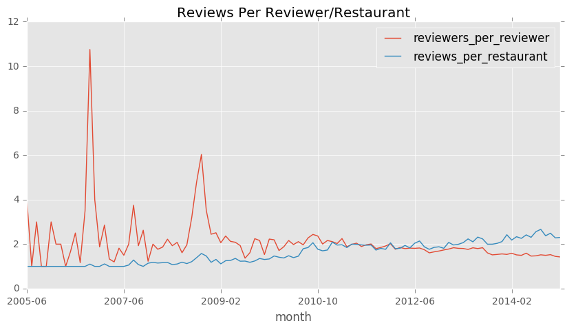

```python
# -Engagement over time
#print review.review_date.min(), review.review_date.max() # 2004 and 2015 didn't have complete month/year
review['month'] = review.review_date.str[:7]
review['year'] = review.review_date.str[:4]
con_ex = (review.year<'2015') & (review.year>'2004')
gp_mh = review[con_ex].groupby('month')
gp_yr = review[con_ex].groupby('year')

# -overall:
print 'Overall:'
from prettypandas import PrettyPandas as pp
ct_overall = gp_yr['review_id','reviewer_id','business_id'].agg(lambda x: x.nunique())
ct_overall.columns = ['reviews','reviewers','restaurants']
ct_overall['delta_reviews'] = ct_overall.reviews.pct_change()
ct_overall['delta_reviewers'] = ct_overall.reviewers.pct_change()
ct_overall['delta_restaurants'] = ct_overall.restaurants.pct_change()
pp(ct_overall[ct_overall.index>'2005']).as_percent([i for i in ct_overall.columns if 'delta' in i])

# -per reviewer/restaurant
rpb = review[con_ex].groupby(['month','business_id'], as_index=False).size().reset_index().groupby(['month'])[0].mean()
rpr = review[con_ex].groupby(['month','reviewer_id'], as_index=False).size().reset_index().groupby(['month'])[0].mean()
df_per = pd.DataFrame({'reviewers_per_reviewer': rpr, 'reviews_per_restaurant':rpb})
df_per.plot(title='Reviews Per Reviewer/Restaurant', figsize=(10,5))
```

```python
# -outlier in Nov 2006
#rpr.sort_values(ascending=False)
#rpr.plot(kind='box');
#review[review.month=='2006-11'].groupby('reviewer_id').size().sort_values(ascending=False)

# -one reviewer gave 37 reviews that month
#reviewer[reviewer.reviewer_id =='K5dxGhJ99TmS6La6krwkcg']
review[['review_stars','review_text']][review.reviewer_id =='K5dxGhJ99TmS6La6krwkcg'].sample(10) # reviews all seem legit

# -but he doesn't usually write as many review in a month...
avg = review[review.reviewer_id =='K5dxGhJ99TmS6La6krwkcg'].groupby('month').size().mean()
print 'One reviewer wrote 37 in Nov 2006. The reviews seem legit but he usually writes only {} reviews per month.' .format(round(avg, 2))
```

|  | review_stars | review_text |
| --- | --- | --- |
| 10391 | 3.0 | This is your typical nice American restaurant.... |
| 9765 | 4.0 | Luisa's has amazing pizza. This place might g... |
| 13980 | 2.0 | I went to the Fig Tree thinking it was going t... |
| 18573 | 4.0 | This new location is just as good as the one i... |
| 6350 | 4.0 | This is the original Bojangles, but they have ... |
| 10524 | 3.0 | Shun Lee was the best place in town to get Chi... |
| 5922 | 4.0 | Yummmmmm! This place has great sandwiches and... |
| 7025 | 4.0 | This place is surprisingly cozy and inviting, ... |
| 15653 | 5.0 | This is the best Indian food in town. This pl... |
| 9574 | 4.0 | This place has great food. I love the chicken... |

```
One reviewer wrote 37 in Nov 2006. The reviews seem legit but he usually writes only 4.13 reviews per month.
```

# Modeling and testing

## - What leads to more reviews?

- full bar (+) and price range (+)
- Bars/Night life get more reviews

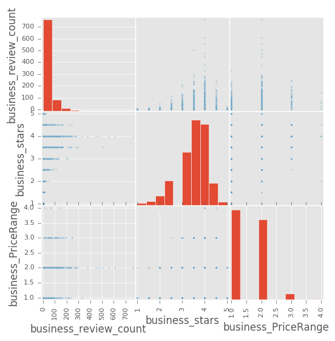

```python
# -scatter
var = ['business_review_count','business_stars','business_PriceRange']
from pandas.tools.plotting import scatter_matrix
scatter_matrix(business[var], alpha=0.2, figsize=(6, 6), diagonal='hist');
```

```python
# -multiple regression
import statsmodels.formula.api as smf
features = 'business_PriceRange+ C(business_Alcohol)+ C(business_NoiseLevel)+ C(business_HasTV)'
est = smf.ols(formula='business_review_count ~'+features, data=business).fit()
est.summary().tables[1]
```

|  | coef | std err | t | P>\|t\| | [95.0% Conf. Int.] |
| --- | --- | --- | --- | --- | --- |
| Intercept | 40.0940 | 8.152 | 4.919 | 0.000 | 24.100 56.088 |
| C(business_Alcohol)[T.full_bar] | 13.0623 | 5.591 | 2.336 | 0.020 | 2.092 24.033 |
| C(business_Alcohol)[T.none] | -27.2568 | 5.546 | -4.915 | 0.000 | -38.139 -16.375 |
| C(business_NoiseLevel)[T.loud] | -13.9282 | 6.001 | -2.321 | 0.020 | -25.703 -2.154 |
| C(business_NoiseLevel)[T.quiet] | -21.1932 | 4.843 | -4.376 | 0.000 | -30.696 -11.691 |
| C(business_NoiseLevel)[T.very_loud] | -31.5639 | 10.405 | -3.033 | 0.002 | -51.980 -11.148 |
| C(business_HasTV)[T.True] | -9.4195 | 4.176 | -2.256 | 0.024 | -17.613 -1.226 |
| business_PriceRange | 17.4396 | 3.945 | 4.421 | 0.000 | 9.700 25.179 |

```python
# -standardize the restaurant types
ctg = set([i for ctgs in business.business_categories.str.split(', ') for i in ctgs])
ctg = set(i.replace(']','').replace('[','') for i in ctg)
ctg = set('American' if 'American' in i else i for i in ctg)

dict_ctg = {}
for i in list(ctg):
    dict_ctg[i] = len(business[business.business_categories.str.contains(i)])

df_ctg = pd.DataFrame.from_dict(dict_ctg, orient='index')
df_ctg.sort_values(0, ascending=False, inplace=True)
df_ctg.columns=['count_of_restaurant_type']
exclude = np.asarray(['Restaurants','Food','Fast Food']) # exclude some broad terms
df_ctg = df_ctg[(~df_ctg.index.isin(exclude))]
df_ctg = df_ctg[df_ctg.count_of_restaurant_type>100] # picked the top 7 types

# -add restaurants categories as features
for i in df_ctg.index:
    business[i] = False
    business.loc[business.business_categories.str.contains(i), i] = True

# -categories vs stars and reviews
df_ctg['avg_reviews']=0
df_ctg['avg_stars']=0
for i in df_ctg.index:
    df_ctg.avg_reviews.ix[i] = business[business[i] == True]['business_review_count'].mean()
    df_ctg.avg_stars.ix[i] = business[business[i] == True]['business_stars'].mean()
df_ctg
```

|  | count_of_restaurant_type | avg_reviews | avg_stars |
| --- | --- | --- | --- |
| American | 312 | 54.717949 | 3.466346 |
| Bars | 193 | 63.176166 | 3.409326 |
| Sandwiches | 167 | 22.724551 | 3.443114 |
| Nightlife | 146 | 60.917808 | 3.407534 |
| Burgers | 127 | 34.937008 | 3.082677 |
| Pizza | 126 | 32.023810 | 3.388889 |
| Mexican | 105 | 41.800000 | 3.504762 |

## - What leads to higher review stars?

- loud (-) & WheelcharAccessible (+)
- Burgers places get lower stars

```python
# -multiple regression
features = 'C(business_NoiseLevel)+ C(business_WheelchairAccessible)'
est = smf.ols(formula='business_stars ~'+features, data=business).fit()
est.summary().tables[1]
```

|  | coef | std err | t | P>\|t\| | [95.0% Conf. Int.] |
| --- | --- | --- | --- | --- | --- |
| Intercept | 3.1973 | 0.089 | 35.735 | 0.000 | 3.022 3.373 |
| C(business_NoiseLevel)[T.loud] | -0.2860 | 0.074 | -3.866 | 0.000 | -0.431 -0.141 |
| C(business_NoiseLevel)[T.quiet] | 0.0045 | 0.061 | 0.075 | 0.941 | -0.115 0.124 |
| C(business_NoiseLevel)[T.very_loud] | -0.4614 | 0.130 | -3.556 | 0.000 | -0.716 -0.207 |
| C(business_WheelchairAccessible)[T.True] | 0.4266 | 0.092 | 4.663 | 0.000 | 0.247 0.606 |

## - Target restaurants for sales

- 16% of restaurants changed at least half a star from 2013 to 2014

```python
# -restaurants with significant drop in reviews/stars (retro at 2014-12-31)
target = pd.DataFrame()
target['past_mh'] = review[review.month=='2014-12'].groupby(['business_id']).size()
target['mh_before'] = review[review.month=='2014-11'].groupby(['business_id']).size()
target['drop'] = 1-target.past_mh/target.mh_before
target = target.sort_values(by=['drop'], ascending=False)
pp(target.head(10)).as_percent('drop')
```

| business_id | past_mh | mh_before | drop |
| --- | --- | --- | --- |
| DtrACWjoGtx4lAaNfxHS4A | 1 | 8 | 88% |
| rd3PEVYGnW3BOzC4z5oLKQ | 1 | 7 | 86% |
| 6Le3aK5pUrGZaRVMGS0H7w | 1 | 6 | 83% |
| 9wMVSKNAtQ4HFZjHNlruFw | 1 | 5 | 80% |
| Y7uV0B860k14puWuYWuLow | 1 | 4 | 75% |
| tivpU-VNABjNlHZ_sMUDGw | 1 | 4 | 75% |
| foUl4SFiClz_5yP3dy4yrw | 1 | 4 | 75% |
| TQU6uoswhbcI2Mj3EV505w | 1 | 4 | 75% |
| S0EZSHGPt1gd7FzFC_donA | 1 | 4 | 75% |
| EOu5kwsz9XPyq5r-eWrOFQ | 1 | 4 | 75% |

```python
# ratio of restaurants having changed stars in the past year
stars_change = pd.DataFrame()
stars_change['stars_2014'] = review[review.year=='2014'].groupby(['business_id'])['review_stars'].mean()
stars_change['reviews_2014'] = review[review.year=='2014'].groupby(['business_id']).size()
stars_change['stars_2013'] = review[review.year=='2013'].groupby(['business_id'])['review_stars'].mean()
stars_change['reviews_2013'] = review[review.year=='2013'].groupby(['business_id']).size()
stars_change['abs_change'] = abs(stars_change.stars_2014-stars_change.stars_2013)
res_filtered = stars_change[(stars_change.reviews_2014>10)&(stars_change.reviews_2013>10)] # filter out restaurants with very few reviews
r = 1.*len(res_filtered[res_filtered.abs_change>=.5])/len(res_filtered)
print 'Based on {} restaurants with at least 10 reviews each year, {:.1%} have a change of at least half a star from 2013 to 2014.'.format(len(res_filtered),r)
```

```
Based on 332 restaurants with at least 10 reviews each year, 16.0% have a change of at least half a star from 2013 to 2014.
```

## - User analysis

```python
# -measure valuable users - quality
reviewer['elite_ever'] = 0
reviewer.loc[(reviewer.reviewer_years_elite+reviewer.reviewer_currently_elite)>0, 'elite_ever'] = 1
reviewer['quality'] = reviewer.reviewer_num_compliments/reviewer.reviewer_review_count
est = smf.ols(formula='quality ~ reviewer_num_friends+elite_ever', data=reviewer).fit()
est.summary().tables[1]
```

|  | coef | std err | t | P>\|t\| | [95.0% Conf. Int.] |
| --- | --- | --- | --- | --- | --- |
| Intercept | 0.0957 | 0.004 | 24.327 | 0.000 | 0.088 0.103 |
| reviewer_num_friends | 0.0048 | 7.01e-05 | 67.924 | 0.000 | 0.005 0.005 |
| elite_ever | 0.2996 | 0.013 | 23.520 | 0.000 | 0.275 0.325 |

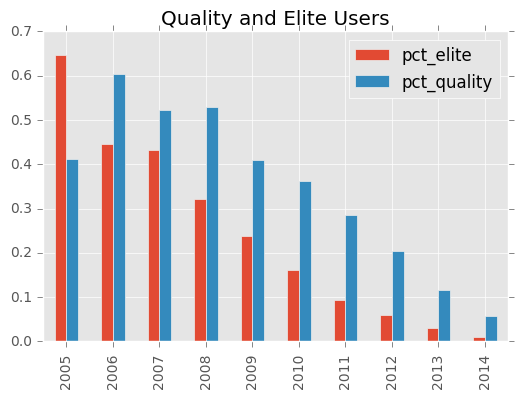

```python
# -quality users/elite over time
usr_quality = reviewer[reviewer.quality>0.16]
usr_elite = reviewer[reviewer.elite_ever>0]
def yr_count(df):
    yr = df.reviewer_yelper_since.str[:4]
    return df[(yr<>'2004')&(yr<>'2015')].reviewer_yelper_since.str[:4].value_counts()
usr = pd.DataFrame({'quality':yr_count(usr_quality), 'elite':yr_count(usr_elite), 'all':yr_count(reviewer)})
usr['pct_elite'] = usr.elite/usr['all']
usr['pct_quality'] = usr.quality/usr['all']
usr[['pct_elite', 'pct_quality']].sort_index().plot(kind='bar', title = 'Quality and Elite Users')
#usr.quality.pct_change()[usr.index>'2011'].mean()
```

## - Reviews

|  | coef | std err | t | P>\|t\| | [95.0% Conf. Int.] |
| --- | --- | --- | --- | --- | --- |
| Intercept | 0.2451 | 0.009 | 27.689 | 0.000 | 0.228 0.262 |
| len | 0.0009 | 9.98e-06 | 93.861 | 0.000 | 0.001 0.001 |

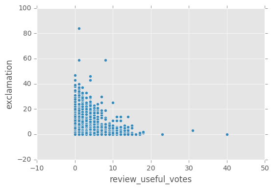

```python
# len vs useful?
review['len'] = review.review_text.apply(len)
est = smf.ols(formula='review_useful_votes ~ len', data=review).fit()
est.summary().tables[1]
# count !
review['exclamation'] = review.review_text.str.count('!')
review.plot(kind='scatter', y='exclamation', x='review_useful_votes')
```